# Statistical Inference: Project report

## Part 1 -Introduction

This project investigates the exponential distribution in R and compares it with the Central Limit Theorem. The exponential distribution can be simulated in R with rexp(n, lambda) where lambda is the rate parameter. The mean of exponential distribution is 1/lambda and the standard deviation is also 1/lambda. Lambda is se to 0.2 for all of the simulations. Simulations are repeated thousand times with samples of 40 numbers generated with exponential distribution.

It will ilustrate via simulation and associated explanatory text the properties of the distribution of the mean of 40 exponentials. It should

1. Show the sample mean and compare it to the theoretical mean of the distribution.
2. Show how variable the sample is (via variance) and compare it to the theoretical variance of the distribution.
3. Show that the distribution is approximately normal.

## Calculating sample’s mean and variation

```r
library(data.table)
library(ggplot2)
library(gridExtra)

listMeans <- data.table(unlist(lapply(1:1000, function (x) { mean(rexp(40, 0.2)) })))
listVariance <- data.table(unlist(lapply(1:1000, function (x) { sd(rexp(40, 0.2)) })))
setnames(listMeans, "listMeans")
setnames(listVariance, "listVariance")
Mean <- mean(listMeans[,listMeans])
MeanVariance <- mean(listVariance[,listVariance])
```

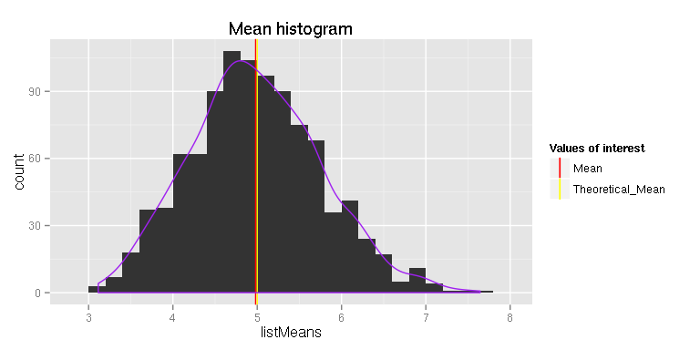

```r
ggplot(listMeans, aes(x=listMeans)) +
  geom_histogram(bin=0.2) +
  ggtitle("Mean histogram") +
  geom_vline(aes(xintercept = Mean,colour = "Mean"),show_guide = TRUE) +
  geom_vline(aes(xintercept = 1/0.2,colour = "Theoretical_Mean"),show_guide = TRUE) +
  geom_density(aes(y = 0.2 * ..count..), colour = "purple") +
  scale_colour_manual(name="Values of interest", values=c(Theoretical_Mean="yellow",Mean="red"))
```

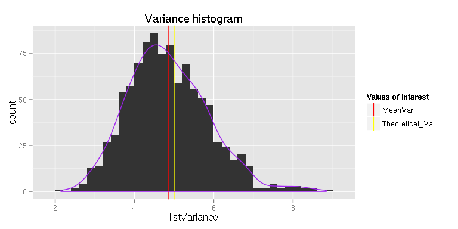

```r
ggplot(listVariance, aes(x=listVariance)) +
  geom_histogram(bin=0.2) +
  ggtitle("Variance histogram") +
  geom_vline(aes(xintercept = MeanVariance,colour = "MeanVar"),show_guide = TRUE) +
  geom_vline(aes(xintercept = 1/0.2, colour = "Theoretical_Var"),show_guide = TRUE) +
  geom_density(aes(y = 0.2 * ..count..), colour = "purple") +
  scale_colour_manual(name="Values of interest", values=c(Theoretical_Var="yellow",MeanVar="red"))
```

## ToothGrowth data analysis

ToothGrowth dataset cotnains data on the effects of vitamin C on tooth growth in guinea pigs. The response is the length of odontoblasts (teeth) in each of 10 guinea pigs at each of three dose levels of Vitamin C (0.5, 1, and 2 mg) with each of two delivery methods (orange juice or ascorbic acid).

A data frame with 60 observations on 3 variables.

[,1] len numeric Tooth length [,2] supp factor Supplement type (VC or OJ). [,3] dose numeric Dose in milligrams.

The following code plots histogram for each of the variables:

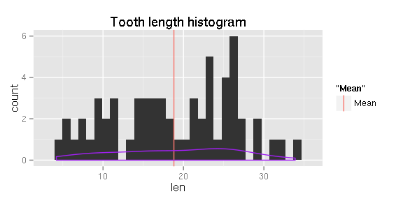

```r
ToothGrowth <- data.table(ToothGrowth)
ggplot(ToothGrowth, aes(x=len)) +
  geom_histogram() +
  ggtitle("Tooth length histogram") +
  geom_vline(aes(xintercept = mean(ToothGrowth[,len]),colour = "Mean"),show_guide = TRUE) +
  geom_density(aes(y = 0.2 * ..count..), colour = "purple")
```

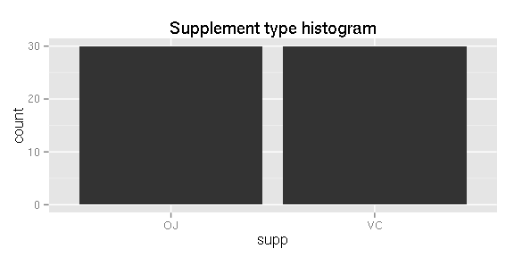

```r
ggplot(ToothGrowth, aes(x=supp)) +
  geom_histogram(bin=0.5) +
  ggtitle("Supplement type histogram")
```

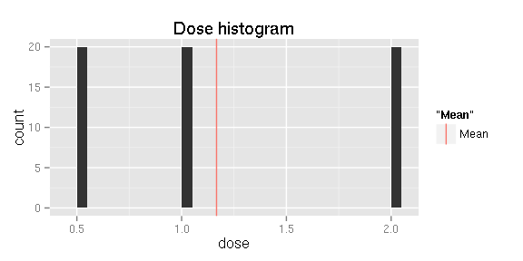

```r
ggplot(ToothGrowth, aes(x=dose)) +
  geom_histogram() +
  ggtitle("Dose histogram") +
  geom_vline(aes(xintercept = mean(ToothGrowth[,dose]),colour = "Mean"),show_guide = TRUE)
```